# Reproducible Research using Quarto & Github

**Dr. Ajay Kumar Koli** |

Digital Humanities Bootcamp Nov. 28, 2026  
School of Humanities, Social Sciences, & Liberal Arts - SGT University

## Today’s Plan

| Time | Block | You will |
| --- | --- | --- |
| 10:00 | Why reproducibility | Understand the problem |
| 10:20 | Meet RStudio and Quarto | Render your first document |
| 10:40 | Writing in Markdown | Write about your research |
| 11:00 | R without fear | Make a table and a chart |
| 11:30 | *Break (10 min)* |  |
| 11:40 | From analysis to report | Add citations and live numbers |
| 12:05 | GitHub in plain words | Save your work with history |
| 12:35 | Publish and share | Get a public link |
| 12:50 | Wrap-up | Checklist and next steps |

## Setup Check

1. [R](https://www.r-project.org/) & [RStudio](https://posit.co/downloads) are installed
2. Open RStudio
3. In the Console, type this and press Enter:

```r
R.version.string
```

4. Install this workshop’s packages (once):

```r
install.packages(c("tidyverse", "gapminder"))
```

5. Open the **Terminal** tab and type `quarto --version`

Stuck? Raise your hand.

# Why Reproducibility?

## A familiar story

`paper_final.docx`  
`paper_final_v2.docx`  
`paper_FINAL_really.docx`  
`paper_FINAL_really_Ajay.docx`

- Which data file made *this* table?
- Who typed *this* number into Word?
- What did we change after the reviewer’s comments?
- Can I redo it in six months?

## When it goes wrong

- In 2010, an influential economics paper on public debt was cited in policy debates about austerity
- In 2013, **a graduate student** tried to repeat the analysis and found a spreadsheet error
- The result was only found because the calculation could be re-run and inspected

Reproducibility is not about distrust. It lets others, and **future you**, see exactly how a number was produced.

Read more https://www.bbc.com/news/magazine-22223190

## What do we mean?

> **Reproducible:** same data + same code = same results, and anyone can re-run it.
- Not “trust me”: **show me**, and let me run it
- Works for numbers, tables, charts and the text around them
- It is a habit, not a special tool

## Our Goal Today

Data

Text

Code

→

**one `.qmd` file**

→

HTML report

Word / PDF

Slides

*These very slides are made this way.*

# Meet RStudio & Quarto

## RStudio has four panes

**Source**  
where you write your document

**Environment**  
objects R is holding in memory

**Console**  
where R runs commands and answers

**Files / Plots / Help**  
your folders, charts and help pages

## What is a `.qmd` file?

````markdown
---
title: "My report"
format: html
---

## Introduction

This is **text** written in Markdown.

```{r}
2 + 2
```
````

Three parts: the **header** (between `---`), the **text**, and **code chunks**.

## Your first render

1. **File → Open File…** and open `workshop-report.qmd`
2. Click **Render** (the blue arrow)
3. Look at the preview that appears
4. Change the **title**, then render again

You just made a document from a plain-text file. That is the whole idea.

# Writing in Markdown

## Markdown in five minutes

| You type | You get |
| --- | --- |
| `## Heading` | a section heading |
| `**bold**` and `*italic*` | **bold** and *italic* |
| `- item` | a bullet list |
| `1. item` | a numbered list |
| `[text](https://quarto.org)` | a link |
| `![caption](photo.png)` | an image |

## The header controls everything

```yaml
---
title: "My first reproducible report"
author: "Your name"
format:
  html:
    embed-resources: true
---
```

Change `html` to `docx` and render again: **same content, new format.**

## Write about your research

1. Under **About my research**, write about 150 words
2. Use at least one **bold** word, one list and one link
3. Render to **HTML**
4. Change `html` to `docx` and render to **Word**

# R without Fear

## Code chunks

Code lives in **chunks**. Click ▶ (or Ctrl/Cmd + Enter) to run.

```r
# add two numbers is a comment
2 + 2
```

```
[1] 4
```

```r
x <- 5
x * 3
```

```
[1] 15
```

- `<-` means “store this under a name”
- Lines starting with `#` are comments for humans

## Our data: Gapminder

```r
library(gapminder)
head(gapminder, 5)
```

```
# A tibble: 5 × 6
  country     continent  year lifeExp      pop gdpPercap
  <fct>       <fct>     <int>   <dbl>    <int>     <dbl>
1 Afghanistan Asia       1952    28.8  8425333      779.
2 Afghanistan Asia       1957    30.3  9240934      821.
3 Afghanistan Asia       1962    32.0 10267083      853.
4 Afghanistan Asia       1967    34.0 11537966      836.
5 Afghanistan Asia       1972    36.1 13079460      740.
```

One row per country per year: **life expectancy**, **population** and **GDP per capita**.

Know more about `gapminder` https://jennybc.github.io/gapminder/articles/gapminder.html

## Keep only what you need

```r
library(dplyr)
filter(gapminder, country == "India", year == 2007)
```

```
# A tibble: 1 × 6
  country continent  year lifeExp        pop gdpPercap
  <fct>   <fct>     <int>   <dbl>      <int>     <dbl>
1 India   Asia       2007    64.7 1110396331     2452.
```

`filter()` keeps rows. Read it aloud: *“from gapminder, keep India in 2007”*.

## A first chart

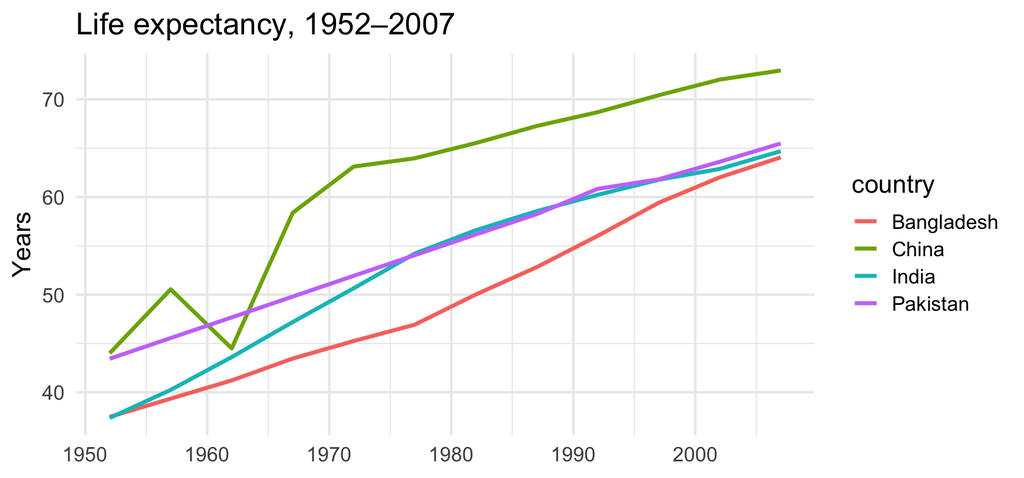

```r
library(ggplot2)
four <- filter(gapminder,
               country %in% c("India", "China", "Bangladesh", "Pakistan"))
ggplot(four, aes(x = year, y = lifeExp, colour = country)) +
  geom_line(linewidth = 1.2) +
  labs(title = "Life expectancy, 1952–2007", x = NULL, y = "Years") +
  theme_minimal(base_size = 16)
```

## Errors are normal

Everyone sees red text. Read the **last line** first.

| You see | Usually means |
| --- | --- |
| `unexpected symbol` | a missing quote, comma or bracket |
| `object 'x' not found` | a typo in a name |
| `there is no package called` | run `install.packages("name")` |

## Table and chart

In `workshop-report.qmd`, fill in the three empty chunks:

1. `head(gapminder, 5)`
2. `filter(gapminder, country == "India", year == 2007)`
3. A line chart for **three or four countries you choose**

Render after each step.

# From Analysis to Report

## Show the result, hide the code

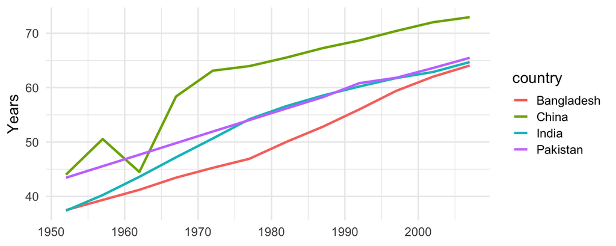

Life expectancy in four South Asian and East Asian countries, 1952–2007.

Chunk options start with `#|`: `echo: false` hides code, `fig-cap` adds a caption.

## Numbers that update themselves

Write this in your text:

```markdown
In 2007, life expectancy in India was `r round(india$lifeExp, 1)` years.
```

Change the data, render again, and the sentence **fixes itself**.

## Citations

1. Save references in `references.bib`
2. Point to it in the header: `bibliography: references.bib`
3. Cite in text: `[@koli2021]`

Quarto builds the reference list for you, in the style you choose.

## One source, many formats

```yaml
format:
  html: default
  docx: default
  pdf: default
```

Same file. Reviewers get Word, readers get HTML, you keep **one** source of truth.

PDF needs a LaTeX or Typst setup; skip it today if it is not installed. Open **terminal** and try `quarto install tinytex`

## Add the finishing touches

1. Write **two sentences** interpreting your chart
2. Put **one number** from the data inside them with inline code
3. Copy `references.bib` into your folder, add `bibliography: references.bib` to the header, and cite `[@koli2021]`
4. Hide the code in your chart chunk and add a **caption**
5. Render

# GitHub in Plain Words

## Git and GitHub, by analogy

| In Word | In Git / GitHub |
| --- | --- |
| Track Changes | **commit**: a saved snapshot with a note |
| `final_v2.docx` | **history**: every version, automatically |
| Shared folder | **repository**: your project, online |
| Email attachment | **GitHub**: a link anyone can open |

A commit message says *why*: “Add life expectancy chart”.

## A tidy project folder

```
my-first-report/
├── index.qmd          # the document
├── references.bib     # citations
├── data/              # raw data, never edited by hand
└── README.md          # how to run it
```

- Use **relative paths** (`data/file.csv`), never `C:/Users/...`
- No spaces in names: `life-expectancy.csv`

## Put your project on GitHub

1. Go to **github.com**, sign in, click **New repository**
2. Name it `my-first-report`, choose **Public**, tick **Add a README**, click **Create**
3. **Add file → Upload files**, drop in your project files, click **Commit changes**
4. Click `index.qmd` → pencil icon ✎ → change the title → **Commit changes**
5. Open the **History** (clock icon) and see both commits

# Publish and Share

## Get a public link

1. Render `index.qmd` with `embed-resources: true` so it becomes **one file**: `index.html`
2. In your repository: **Add file → Upload files**, add `index.html`, commit
3. **Settings → Pages**
4. Source: **Deploy from a branch** → `main` → `/ (root)` → **Save**
5. After 1 to 2 minutes your page is at `https://USERNAME.github.io/my-first-report/`

Open the link on a internet connected device.

## Reproducibility checklist

- Raw data kept untouched in `data/`
- Every step is in code, not mouse clicks
- One file rebuilds the whole report
- Relative paths only
- Packages noted (try `sessionInfo()` at the end)
- A README says how to run it
- History saved on GitHub with clear messages

## Where to go next

- **Quarto guide:** http://quarto.org/docs/guide
- **R for Data Science (2e):** http://r4ds.hadley.nz
- **Happy Git with R:** http://happygitwithr.com
- **ggplot2:** http://ggplot2.tidyverse.org

# Thank you!

*Reproduciblity is a habit.*

Questions?